# Yelp Rating Prediction Based on Text Review Sentiment Analysis

March 29, 2018

## Databook

## Databook: Variables

- **yelp**: csv dataset
- **yelp_clean**: yelp + tokenized df
- **yelp_negative**: 1 star review df
- **yelp_positive**: 5 star review df
- **yelp_class_complete**: 1 - 5 star review df
- **yelp_class_boundary**: 1 and 5 star review df
- **X_complete**: yelp_class['text'] for the complete df
- **y_complete**: yelp_class['stars'] for the complete df
- **X_boundary**: yelp_class['text'] for the reduced df
- **y_boundary**: yelp_class['stars'] for the reduced df

## Databook: Variables

- **X_train**: training set for respective yelp_class['text'] df subset
- **X_test**: testing set for respective yelp_class['text'] df subset
- **y_train**: training set for respective yelp_class['stars'] df subset
- **y_test**: testing set for respective yelp_class['stars'] df subset
- **classifier_nb**: naive bayes classifier
- **classifier_linear**: linear SVM classifier
- **classifier_linear_library**: linear SVM classifier from LinearSVC library
- **classifier_logistic_regression**: logistic regression classifier
- **t0, t1, t2**: timestamp

## Databook: Variables

- **prediction**: set of predictions for a unique classifier
- **time_train**: training time
- **time_predict**: prediction time
- **score**: accuracy for a unique classifier
- **cm**: convolutional matrix for a unique classifier
- **fpr**: false positive rate
- **tpr**: true positive rate
- **roc_auc**: area under curve of a ROC for a unique classifier

## Databook: Functions

- **convert(x)**: convert json line into csv **return**: csv object
- **text_process(text)**: preprocess text string **return**: array of words
- **convert_review_large_csv(override)**: convert full yelp json dataset
- **clean_dataset(yelp)**: retype df, append 'length' and 'tokenized' **return**: processed dataset
- **create_class(yelp, boundary)**: generate df from yelp dataset based on the boundary boolean **return**: yelp df
- **generate_X_y(yelp_class)**: generate 'text' and 'stars' df **return**: 'text' and 'stars' df
- **bow_transformer(X)**: bag of words transformer **return**: bow fit and transformed df

## Dataset

## Cleaned Dataset

```
def clean_dataset(yelp):
    yelp['text'] = yelp['text'].astype(str)
    yelp['length'] = yelp['text'].apply(len)
    yelp['tokenized'] = yelp.apply(lambda row: text_process(row['text']),
      axis=1)
    yelp.to_csv('review_small_clean_tokenized.csv', encoding='utf-8',
      index=False)

    return yelp
```

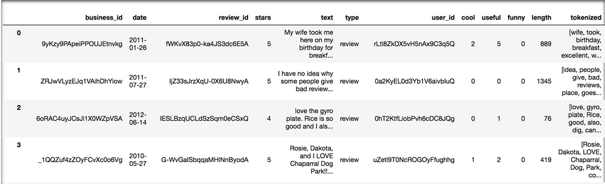

## Stars v. Length

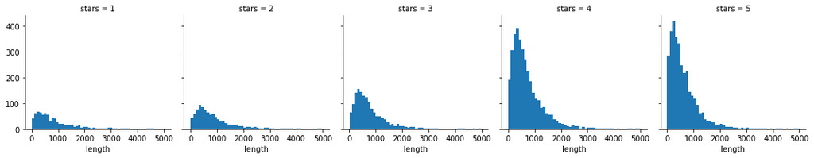

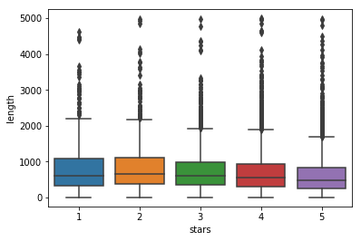

## Stars Count

As shown the reduced dataset (10,000 yelp datapoints) is offset to higher stars, so we should expect to see more errors in correctly predicting negative reviews over positive reviews.

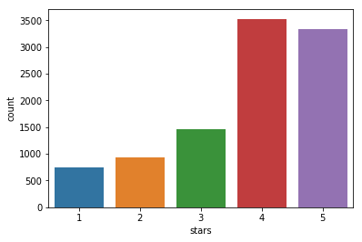

## Correlation Data

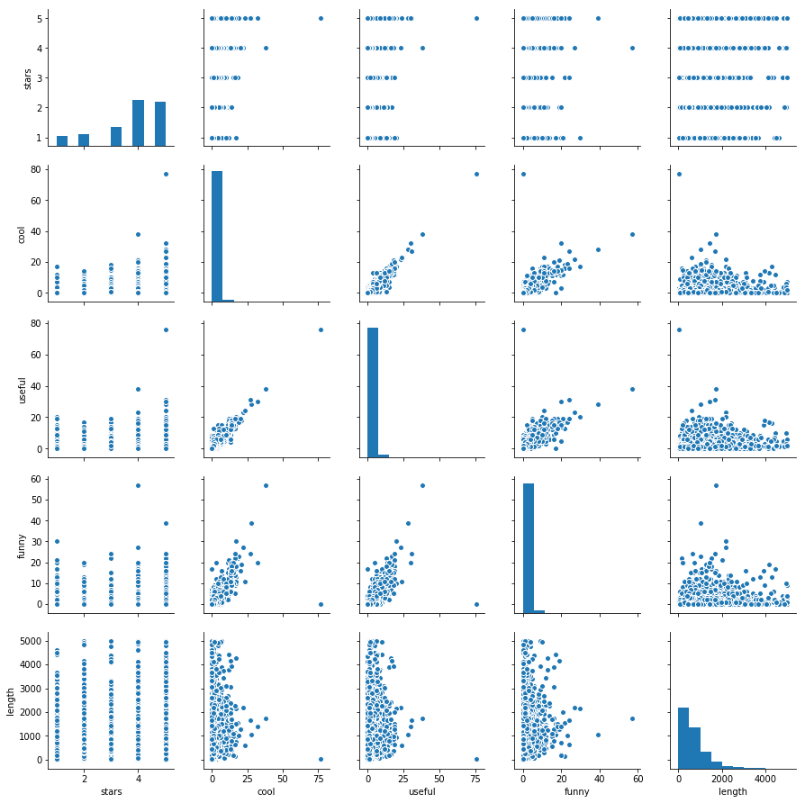

## Word Clouds

Negative

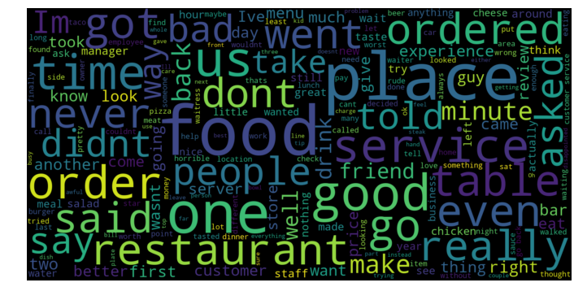

Positive

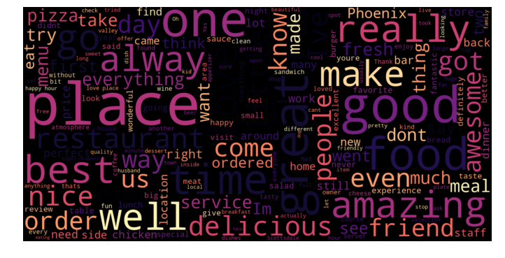

## Complete - Multinomial Naive Bayes Classifier

- Multinomial Naive Bayes Classifier
  - 1 - 5 stars
  - Training time: 0.014833s; Prediction time: 0.002186s
  - Accuracy Score: 0.456666666667
  - 1 & 5 stars
  - Training time: 0.003669s; Prediction time: 0.000688s
  - Accuracy Score: 0.92251223491

## Complete - Multinomial Naive Bayes Classifier

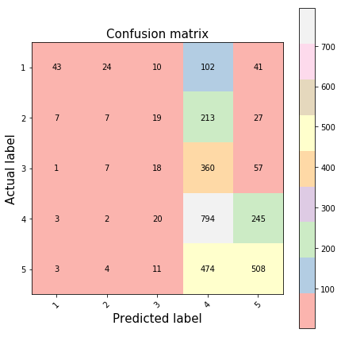

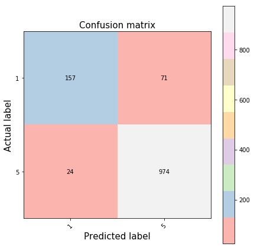

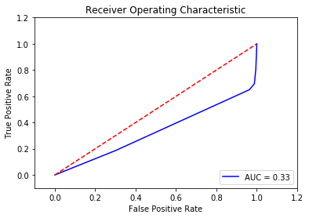

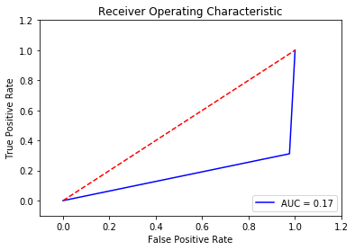

## Complete - Linear SVM Classifier

- Linear SVM Classifier

  ```
  classifier_linear = svm.SVC(kernel='linear')
  ```

## Complete - Linear SVM Classifier

- Linear SVM Classifier

  ```
  classifier_linear_library = svm.LinearSVC()
  ```

## Complete - Linear SVM Classifier

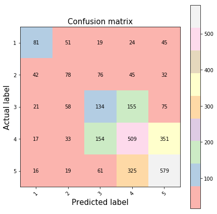

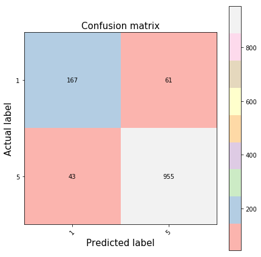

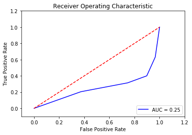

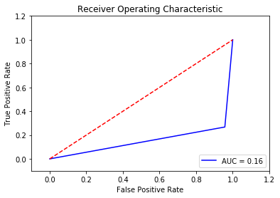

## Complete - Logistic Regression Classifier

- Logistic Regression Classifier
  - 1 - 5 stars
  - Training time: 1.266805s; Prediction time: 0.001917s
  - Accuracy Score: 0.491
  - 1 & 5 stars
  - Training time: 0.040764s; Prediction time: 0.000444s
  - Accuracy Score: 0.91924959217

## Complete - Logistic Regression Classifier

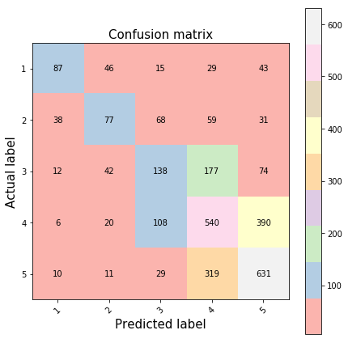

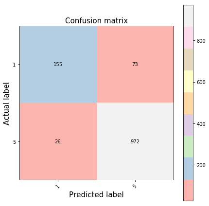

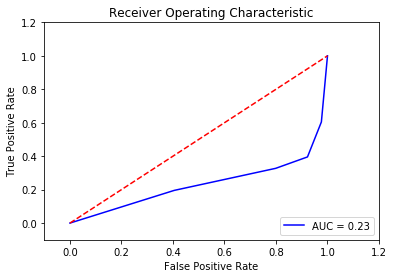

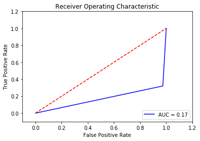

## Up Next

- Figure out why ROC curves are so bad (probably just implimenting them wrong)
- Test and evaluate models on full dataset
  - Maybe setup AWS server to do run my code efficiently